# KNN With Uncertainty Information

## Experiments on Combined Drug Target Dataset

### Integrate Layers

First, we load in the drug target info.

```r
data.bench <- DrugTargetsKNN(common.drugs, gmt_file_name="temp", use.ctrpv2=TRUE,
                        use.clue=TRUE, use.chembl=TRUE, use.dbank=TRUE, use.dtc=FALSE)
data.bench[] <- lapply(data.bench, as.character)
benchmark.drugs <- unique(data.bench$MOLECULE_NAME)
```

Now we create the integrated network.

```r
all.drugs <- common.drugs
correlation.matrices <- list(sens=sens.cor, pert=pert.cor.new, strc=strc.cor)
integrated <- IntegrateCorrelationMatrices(correlation.matrices, all.drugs)
```

Finally, we obtain the leave one out networks.

```r
loo.networks <- CreateLeaveOneOutNetworks(integrated, correlation.matrices, all.drugs, data.bench)
```

### Analyze Neighbour Differences

First, we get the neighbours the old fashioned way by looking at just the subnetwork od drugs with drug target info. Then we look at the full network.

We want to see how many of the top 5 neighbours are in common per drug across the two methods.

```r
k <- 5
top <- 5
neighbours.full <- list()
neighbours.subnet <- list()
for (drug in benchmark.drugs) {
    loo.net <- loo.networks[[drug]]

    neighbours.full[[drug]] <- GetNearestNeighbours(k, loo.net, drug)
    neighbours.subnet[[drug]] <- GetNearestNeighbours(k, loo.net[benchmark.drugs, benchmark.drugs], drug)
}
```

Let’s determine on average how many of the top 5 neighbours are in agreement between the two methods. We’ll be lenient such that order does not matter.

```r
intersection <- list()
for (drug in names(neighbours.full)) {
    temp <- intersect(neighbours.full[[drug]]$neighbours, neighbours.subnet[[drug]]$neighbours)

    intersection[[drug]] <- temp
}
avg.intersection <- mean(unlist(lapply(intersection, length)))
cat(paste("Average overlap between methods in top 5 drugs:", avg.intersection))
```

```
Average overlap between methods in top 5 drugs: 3.72111553784861
```

We can also take a look at some of the worst drugs in terms of the overlap between the two methods.

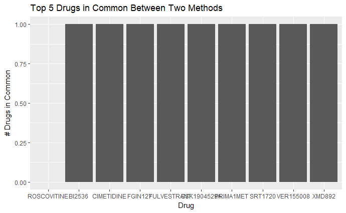

```r
intersection.lengths <- unlist(lapply(intersection, length))
worst.drugs <- head(sort(intersection.lengths), 10)
df.data <- cbind(names(worst.drugs), worst.drugs)
df.data <- as.data.frame(df.data, stringsAsFactors=F)
colnames(df.data) <- c("drug", "intersection")
df.data$intersection <- as.numeric(df.data$intersection)
p <- ggplot(data=df.data, aes(x=reorder(drug, intersection), y=intersection))
p <- p + geom_bar(stat="identity")
p <- p + ggtitle("Top 5 Drugs in Common Between Two Methods")
p <- p + xlab("Drug")
p <- p + ylab("# Drugs in Common")
p
```

Now we can see if there is significant overlap between the drugs that are misclassified by KNN, and the drugs that have the worst intersection between the two neighbours methods.

```r
accuracies <- numeric(length(benchmark.drugs))
names(accuracies) <- benchmark.drugs
for (drug in benchmark.drugs) {
    loo.net <- loo.networks[[drug]]

    acc <- GetKNNAccuracySingle(k, loo.net, data.bench, drug)
    accuracies[drug] <- acc
}
bad.drugs.accuracy <- accuracies[accuracies == 0]
bad.drugs.intersection <- intersection.lengths[intersection.lengths <= 4]
num.common.drugs <- length(intersect(names(bad.drugs.accuracy), names(bad.drugs.intersection)))
percentage.misclassified <- num.common.drugs / length(bad.drugs.accuracy)
cat(paste("Percentage of misclassified drugs in drugs that don't have complete overlap between two nearest neighbours methods:", percentage.misclassified))
```

```
Percentage of misclassified drugs in drugs that don't have complete overlap between two nearest neighbours methods: 0.86
```

Now let’s create a bar plot showing how the percentage of misclassified drugs changes as a function of the number of neighbours in the intersection between the two methods.

```r
bad.drugs <- names(bad.drugs.accuracy)
percentages <- list()
for (i in 0:k) {
    temp <- names(intersection.lengths[intersection.lengths <= i])

    overlap <- length(intersect(bad.drugs, temp))
    percentages[[as.character(i)]] <- overlap / length(bad.drugs)
}
```

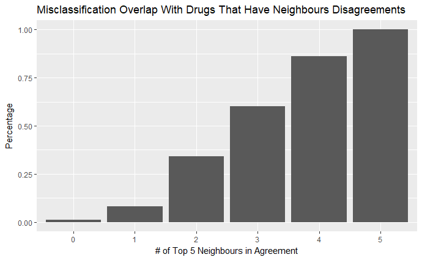

```r
percentages <- unlist(percentages)
df.data <- cbind(names(percentages), percentages)
df.data <- as.data.frame(df.data, stringsAsFactors=F)
colnames(df.data) <- c("neighbour.intersection", "percentage")
df.data$percentage <- as.numeric(df.data$percentage)
p <- ggplot(data=df.data, aes(x=reorder(neighbour.intersection, percentage), y=percentage))
p <- p + geom_bar(stat="identity")
p <- p + ggtitle("Misclassification Overlap With Drugs That Have Neighbours Disagreements")
p <- p + xlab("# of Top 5 Neighbours in Agreement")
p <- p + ylab("Percentage")
p
```